# Data Visualization - Mini-Project 1

Omar Abdallah Mateo `oabdallahmateo8279@floridapoly.edu`

## Load Data

```r
library(tidyverse)
us_births <- read_csv("https://raw.githubusercontent.com/reisanar/datasets/master/us_births_00_14.csv", col_types = cols())
```

## Summary

```r
library(dplyr)

births_summary <- us_births %>%
  group_by(year) %>%
  summarize(total_births = sum(births))

# View the summarized data
print(births_summary)
```

| year | total_births |
| --- | --- |
| 2000 | 4149598 |
| 2001 | 4110963 |
| 2002 | 4099313 |
| 2003 | 4163060 |
| 2004 | 4186863 |
| 2005 | 4211941 |
| 2006 | 4335154 |
| 2007 | 4380784 |
| 2008 | 4310737 |
| 2009 | 4190991 |

[output cut: 5 more lines]

```r
NA
```

## Visualizations

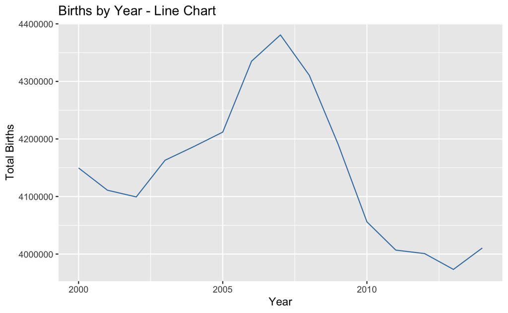

```r
library(ggplot2)

# Line chart
ggplot(births_summary, aes(x = year, y = total_births)) +
  geom_line(color = "steelblue") +
  labs(x = "Year", y = "Total Births", title = "Births by Year - Line Chart")
```

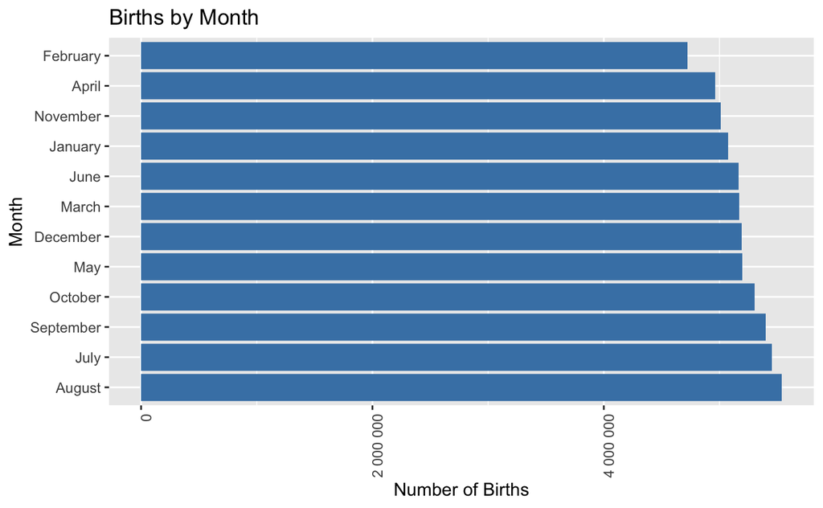

```r
library(ggplot2)
library(scales)
# Convert month to a factor with all levels
us_births$month <- factor(us_births$month, levels = unique(us_births$month),
                          labels = c("January", "February", "March", "April", "May", "June",
                                     "July", "August", "September", "October", "November", "December"))

# Calculate total births by month
births_summary <- us_births %>%
  group_by(month) %>%
  summarize(total_births = sum(births))

# Reorder the levels of the month factor based on total births in descending order
births_summary <- births_summary[order(births_summary$total_births, decreasing = TRUE), ]
us_births$month <- factor(us_births$month, levels = births_summary$month)

# Bar chart of births by month
ggplot(us_births, aes(x = month, y = births)) +
  geom_col(fill = "steelblue") +
  scale_y_continuous(labels = label_number(suffix = "")) +
  labs(x = "Month", y = "Number of Births", title = "Births by Month") +
  theme(axis.text.x = element_text(angle = 90, hjust = 1)) +
  coord_flip()
```

```r
NA
NA
```

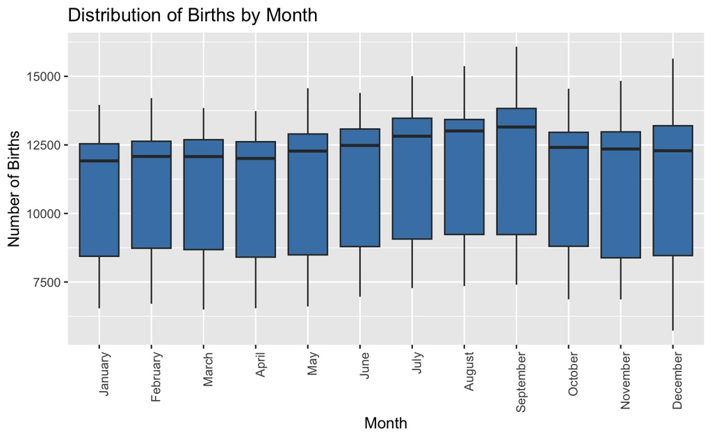

```r
library(ggplot2)

# Convert month to a factor with all levels
us_births$month <- factor(us_births$month, levels = unique(us_births$month),
                          labels = c("January", "February", "March", "April", "May", "June",
                                     "July", "August", "September", "October", "November", "December"))

# Create a boxplot of births by month
ggplot(us_births, aes(x = month, y = births)) +
  geom_boxplot(fill = "steelblue") +
  labs(x = "Month", y = "Number of Births", title = "Distribution of Births by Month") +
  theme(axis.text.x = element_text(angle = 90, hjust = 1))
```

[figure not shown]

```r
library(reshape2)
library(dplyr)

# Convert month and day_of_week to factors with all levels
us_births$month <- factor(us_births$month, levels = unique(us_births$month),
                          labels = c("January", "February", "March", "April", "May", "June",
                                     "July", "August", "September", "October", "November", "December"))
us_births$day_of_week <- factor(us_births$day_of_week, levels = c("Sunday", "Monday", "Tuesday", "Wednesday", "Thursday", "Friday", "Saturday"))

# Summarize births by month and day_of_week
births_summary <- us_births %>%
  group_by(month, day_of_week) %>%
  summarize(total_births = sum(births))
# Reshape the data for creating the heatmap
births_matrix <- dcast(births_summary, day_of_week ~ month, value.var = "total_births")

# Create the heatmap
ggplot(data = births_summary, aes(x = month, y = day_of_week, fill = total_births)) +
  geom_tile() +
  labs(x = "Month", y = "Day of the Week", title = "Number of Births by Month and Day of the Week") +
  scale_fill_gradient(low = "lightblue", high = "darkblue") +
  theme(axis.text.x = element_text(angle = 90, hjust = 1),
        legend.position = "right")
```

```r
NA
NA
```

# Report

## What were the original charts you planned to create for this assignments?

These were the original charts; however, I was facing some issues with the bar chart with the labels, but it is good now.

## What story could you tell with your plots?

I found out that the highest peak of births was on 2007; however after that it decreased drastically. It will be interesting to compare this with the family’s economy since I feel it might be related with the economic crisis of 2008.

I also search throw the months to find out what is the month with the highest number of births. I have always heard that October/November has the highest number of births because of St. Valentine’s day on February, after looking at the graph I can confirm that this legend is false. The month which most births is August.